# R Notebook

## Boruta Feature Selection

Load data

| agg_level | n_distinct(cancer_type) |
| --- | --- |
| 99. | 3 |
| 99.5. | 3 |
| 99.9. | 4 |

#### Analysis of features selection for task of hotspots prediction

For each cancer type and labeling type there were 30 train/test splits which includes 10 different procedures for 5-iteration Boruta FS.

How many iterations were used in datasets?

```r
df_agg <- df %>%
  filter(feature_type == "real") %>%
  group_by(cancer_type, repeat., resample, iter) %>%
  summarize(
    n_selected = sum(hit),
    n_total = n()
    ) %>%
  mutate(
    ratio_selected = n_selected / n_total
  )

df_1_sample <- df_agg %>%
  group_by(cancer_type, repeat., resample) %>%
  filter(max(iter) == 1) %>%
  select(cancer_type, repeat., resample) %>%
  unique()

df_11 <- df_agg %>%
  inner_join(df_1_sample, by = c("cancer_type", "repeat.", "resample")) %>%
  group_by(iter) %>%
  summarize(
    mean_n_selected = mean(n_selected),
    mean_ratio_selected = mean(ratio_selected)
  )

df_2_sample <- df_agg %>%
  group_by(cancer_type, repeat., resample) %>%
  filter(max(iter) == 2) %>%
  select(cancer_type, repeat., resample) %>%
  unique()

df_21 <- df_agg %>%
  inner_join(df_2_sample, by = c("cancer_type", "repeat.", "resample")) %>%
  group_by(iter) %>%
  summarize(
    mean_n_selected = mean(n_selected),
    mean_ratio_selected = mean(ratio_selected)
  )

df_3_sample <- df_agg %>%
  group_by(cancer_type, repeat., resample) %>%
  filter(max(iter) == 3) %>%
  select(cancer_type, repeat., resample) %>%
  unique()

df_31 <- df_agg %>%
  inner_join(df_3_sample, by = c("cancer_type", "repeat.", "resample")) %>%
  group_by(iter) %>%
  summarize(
    mean_n_selected = mean(n_selected),
    mean_ratio_selected = mean(ratio_selected)
  )

df_4_sample <- df_agg %>%
  group_by(cancer_type, repeat., resample) %>%
  filter(max(iter) == 4) %>%
  select(cancer_type, repeat., resample) %>%
  unique()

df_41 <- df_agg %>%
  inner_join(df_4_sample, by = c("cancer_type", "repeat.", "resample")) %>%
  group_by(iter) %>%
  summarize(
    mean_n_selected = mean(n_selected),
    mean_ratio_selected = mean(ratio_selected)
  )

df_5_sample <- df_agg %>%
  group_by(cancer_type, repeat., resample) %>%
  filter(max(iter) == 5) %>%
  select(cancer_type, repeat., resample) %>%
  unique()

df_51 <- df_agg %>%
  inner_join(df_5_sample, by = c("cancer_type", "repeat.", "resample")) %>%
  group_by(iter) %>%
  summarize(
    mean_n_selected = mean(n_selected),
    mean_ratio_selected = mean(ratio_selected)
  )

df_11$max_iter <- 1
df_21$max_iter <- 2
df_31$max_iter <- 3
df_41$max_iter <- 4
df_51$max_iter <- 5

df_stats <- rbind(
  df_11,
  df_21,
  df_31,
  df_41,
  df_51
  )

data.frame(
  n_iters = seq(1, 5),
  n_datasets = c(
    nrow(df_1_sample),
    nrow(df_2_sample),
    nrow(df_3_sample),
    nrow(df_4_sample),
    nrow(df_5_sample))
)
```

| n_iters | n_datasets |
| --- | --- |
| 1 | 1044 |
| 2 | 114 |
| 3 | 91 |
| 4 | 84 |
| 5 | 1667 |

```r
NA
```

How namy features selected on each iteration?

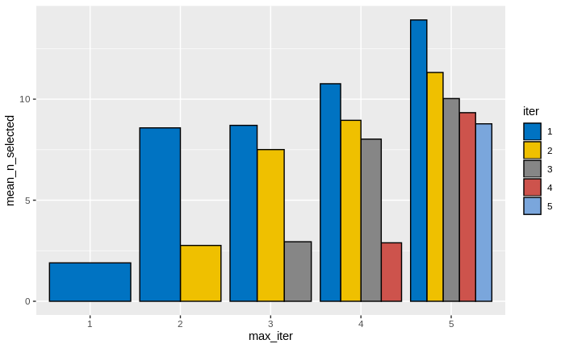

```r
df_stats$max_iter <- as.character(df_stats$max_iter)
df_stats$iter <- as.character(df_stats$iter)

ggplot(df_stats, aes(x=max_iter, fill=iter, y=mean_n_selected)) +
  geom_bar(stat="identity", color="black", position = "dodge")  +
  scale_fill_jco()
```

Typically, 2-3 features are selected if there were less than 5 iterations (or when relatively big number of features were removed at the beginning of the procedure). In contrast, when all 5 iterations were used, lower percent of features were removed ar each iteration and in average 9 features were finally selected.

How namy features selected on each iteration in dependence on cancer type

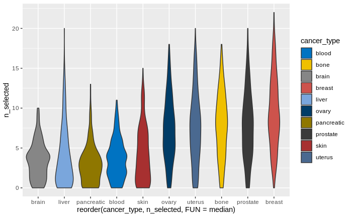

```r
df_last_iter <- df_agg %>%
  group_by(cancer_type, repeat., resample) %>%
  filter(iter == max(iter))

ggplot(df_last_iter,
       aes(x=reorder(cancer_type, n_selected, FUN = median), fill=cancer_type, y=n_selected)) +
  geom_violin() +
  scale_fill_jco()
```

```r
df_last_iter %>%
  group_by(cancer_type) %>%
  summarize(median_iter = median(iter)) %>%
  arrange(median_iter)
```

| cancer_type | median_iter |
| --- | --- |
| brain | 1 |
| liver | 1 |
| pancreatic | 1 |
| blood | 2 |
| skin | 4 |
| bone | 5 |
| breast | 5 |
| ovary | 5 |
| prostate | 5 |
| uterus | 5 |

```r
df_last_iter %>%
  group_by(cancer_type) %>%
  summarize(median_selected = median(n_selected)) %>%
  arrange(median_selected)
```

| cancer_type | median_selected |
| --- | --- |
| brain | 3 |
| liver | 3 |
| pancreatic | 3 |
| blood | 4 |
| skin | 4 |
| ovary | 7 |
| uterus | 7 |
| bone | 8 |
| prostate | 8 |
| breast | 9 |

```r
df_last_iter %>%
  group_by(cancer_type) %>%
  filter(n_selected == 0) %>%
  summarize(n_zero_features = n()) %>%
  arrange(n_zero_features)
```

| cancer_type | n_zero_features |
| --- | --- |
| breast | 1 |
| ovary | 9 |
| bone | 12 |
| prostate | 12 |
| uterus | 19 |
| blood | 29 |
| brain | 30 |
| pancreatic | 47 |
| skin | 47 |
| liver | 50 |

Two groups could be defined:

1. Brain, liver, pancreatic, blood, skin - Median number of iterations is 1-4 with median number of selected features of 3-4. Besides, in 29-50 cases (from 300) no features were selected. All except skin cancer has labeling type 99.9%.
2. Bone, breast, ovary, prostate, uterus - Median number of iterations is 5 with median number of selected features of 7-9. Besides, in 1-19 cases (from 300) no features were selected. Labeling types - 99% and 99.5%

```r
df %>%
  select(cancer_type, agg_level) %>%
  unique()
```

|  | cancer_type | agg_level |
| --- | --- | --- |
| 1 | blood | 99.9. |
| 57817 | bone | 99.5. |
| 122359 | brain | 99.9. |
| 180419 | breast | 99.5. |
| 254107 | liver | 99.9. |
| 310113 | ovary | 99. |
| 376115 | pancreatic | 99.9. |
| 422867 | prostate | 99. |
| 489777 | skin | 99. |
| 548349 | uterus | 99.5. |

For each feature how many times it appeared in final feature set by cancer type

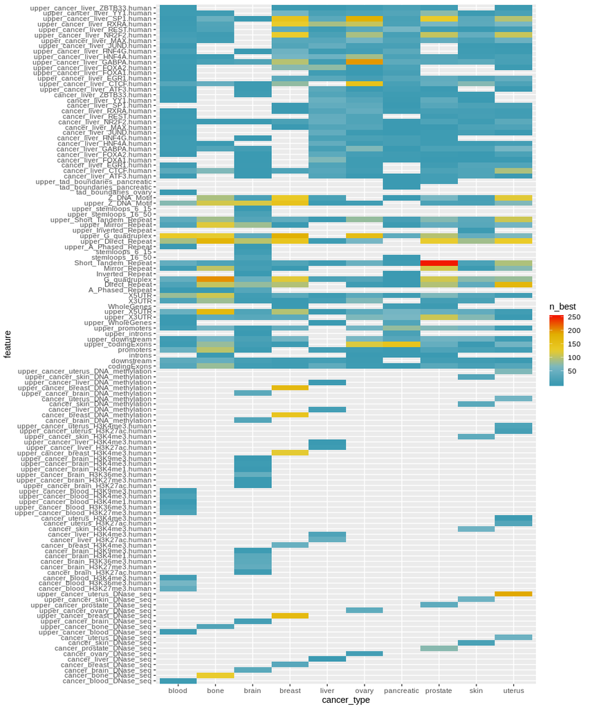

```r
df_all_hits <- df %>%
  filter(feature_type == "real") %>%
  filter(hit == 1)

df_hits_last_iter <- df_all_hits %>%
  group_by(cancer_type, repeat., resample) %>%
  filter(iter == max(iter))

df_hits_last_iter$feature_n <- gsub(x=df_hits_last_iter$feature, pattern = "upper_", replacement = "")
sec_str <- c("A_Phased_Repeat","Direct_Repeat", "Inverted_Repeat", "Mirror_Repeat","Short_Tandem_Repeat",
             "G_quadruplex", "stemloops_16_50", "stemloops_6_15", "Z_DNA_Motif")
reg <- c("X3UTR", "X5UTR", "codingExons", "downstream", "introns", "promoters", "WholeGenes")
tad <- c("tad_boundaries_liver", "tad_boundaries_ovary", "tad_boundaries_pancreatic")
chromatin <-c("cancer_skin_DNase_seq", "cancer_brain_DNase_seq", "cancer_blood_DNase_seq",
              "cancer_prostate_DNase_seq", "cancer_pancreas_DNase_seq", "cancer_ovary_DNase_seq",
              "cancer_liver_DNase_seq", "cancer_breast_DNase_seq", "cancer_uterus_DNase_seq",
              "cancer_bone_DNase_seq")
methyl <- c("cancer_brain_DNA_methylation", "cancer_breast_DNA_methylation",
            "cancer_liver_DNA_methylation", "cancer_pancreas_DNA_methylation",
            "cancer_skin_DNA_methylation", "cancer_uterus_DNA_methylation")
histones <- c( "cancer_liver_H3K27ac.human", "cancer_uterus_H3K27ac.human", "cancer_blood_H3K27ac.human",
               "cancer_brain_H3K27ac.human",
               "cancer_pancreas_H3K27ac.human","cancer_blood_H3K27me3.human","cancer_brain_H3K27me3.human",
               "cancer_blood_H3K36me3.human","cancer_pancreas_H3K36me3.human","cancer_brain_H3K36me3.human",
               "cancer_pancreas_H3K4me1.human","cancer_blood_H3K4me1.human","cancer_brain_H3K4me1.human",
               "cancer_breast_H3K4me3.human","cancer_uterus_H3K4me3.human","cancer_liver_H3K4me3.human",
               "cancer_brain_H3K4me3.human","cancer_blood_H3K4me3.human","cancer_skin_H3K4me3.human",
               "cancer_pancreas_H3K4me3.human","cancer_brain_H3K9me3.human","cancer_pancreas_H3K9me3.human",
               "cancer_blood_H3K9me3.human" )
tf <- c("cancer_liver_ATF3.human", "cancer_liver_CTCF.human", "cancer_pancreas_CTCF.human",
        "cancer_liver_EGR1.human", "cancer_liver_FOXA1.human", "cancer_liver_FOXA2.human",
        "cancer_liver_GABPA.human","cancer_liver_HNF4A.human", "cancer_liver_HNF4G.human",
        "cancer_liver_JUND.human","cancer_liver_MAX.human", "cancer_liver_NR2F2.human",
        "cancer_liver_REST.human", "cancer_liver_RXRA.human", "cancer_liver_SP1.human",
        "cancer_liver_YY1.human", "cancer_liver_ZBTB33.human")

df_hits_last_iter$feature_group <- ifelse(
  df_hits_last_iter$feature_n %in% sec_str, "sec_str",
  ifelse(
    df_hits_last_iter$feature_n %in% reg, "reg",
    ifelse(
      df_hits_last_iter$feature_n %in% tad, "tad",
      ifelse(
        df_hits_last_iter$feature_n %in% chromatin, "chromatin",
        ifelse(
          df_hits_last_iter$feature_n %in% methyl, "methyl",
          ifelse(
            df_hits_last_iter$feature_n %in% histones, "histones", "tf"
        )
        )
      )
    )
  )
)

df_hits_last_iter_agg <- df_hits_last_iter %>%
  group_by(cancer_type, feature, feature_group) %>%
  summarize(n_best = n())

f <- df_hits_last_iter_agg %>%
  ungroup() %>%
  select(feature, feature_group) %>%
  unique() %>%
  arrange(feature_group, feature)

df_hits_last_iter_agg$feature <- with(df_hits_last_iter_agg, factor(feature, levels = f$feature))

ggplot(df_hits_last_iter_agg, aes(x=cancer_type, y=feature,fill=n_best)) +
  geom_tile() +
  scale_fill_gradientn(colours = pal)
```

Aggregation by feature group for each cancer type: number of datasets in which features of the feature group selected.

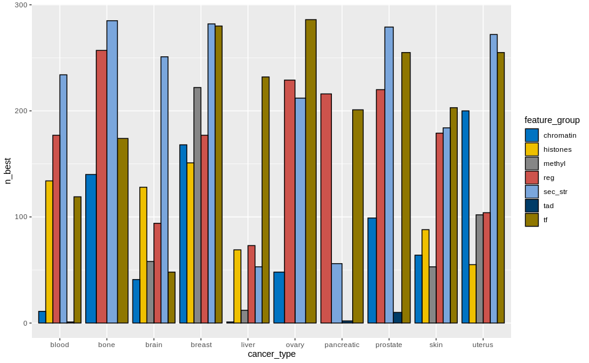

```r
df_hits_last_iter_agg_new <- df_hits_last_iter %>%
  group_by(cancer_type, feature_group) %>%
  summarize(
    n_best = n_distinct(resample, repeat.)
    )

ggplot(df_hits_last_iter_agg_new, aes(x=cancer_type, y=n_best, fill=feature_group))+
  geom_bar(stat="identity", color="black", position="dodge") +
  scale_fill_jco()
```

Выводы:

По типу рака: В более половины датасетов встретились признаки следующих групп:

- blood - вторичные структуры + регионы
- bone - вторичные структуры + регионы + транскрипционные факторы
- brain - вторичные структуры
- breast - вторичные структуры + регионы + транскрипционные факторы + хроматин + метилирование
- liver - транскрипционные факторы
- ovary - вторичные структуры + регионы + транскрипционные факторы
- pancreatic - регионы + транскрипционные факторы
- prostate - вторичные структуры + регионы + транскрипционные факторы
- skin - вторичные структуры + регионы + транскрипционные факторы
- uterus - вторичные структуры + транскрипционные факторы + хроматин

Больше всего важных групп фичей наблюдается для рака груди, меньше всего - для мозга и печени.

По признакам: В целом, нет группы фичей, которая важна для всех типов рака, однако для 8 типов рака важны вторичные структуры и транскрипционные факторы.

В рисунок по фичам не вошли признаки, которые ни разу не появились в финальном наборе фичей.

```r
all_f <- unique(df$feature)
all_f <- setdiff(all_f, grep(x = all_f, pattern = "shadow", value = T))

sel_f <- unique(df_hits_last_iter$feature)

setdiff(all_f, sel_f)
```

```
[1] "tad_boundaries_liver"             "upper_tad_boundaries_liver"       "upper_tad_boundaries_ovary"
[4] "cancer_blood_H3K27ac.human"       "cancer_blood_H3K4me1.human"       "cancer_blood_H3K9me3.human"
[7] "upper_cancer_blood_H3K27ac.human" "cancer_brain_H3K4me3.human"       "upper_cancer_liver_DNase_seq"
```

```r
by_f <- df_hits_last_iter %>%
  group_by(feature_group, feature) %>%
  summarize(
    total_sets = n()
    ) %>%
  arrange(desc(total_sets))
by_f
```

| feature_group | feature | total_sets |
| --- | --- | --- |
| sec_str | upper_Direct_Repeat | 908 |
| sec_str | upper_G_quadruplex | 875 |
| sec_str | G_quadruplex | 726 |
| tf | upper_cancer_liver_SP1.human | 685 |
| sec_str | Direct_Repeat | 611 |
| sec_str | upper_Z_DNA_Motif | 560 |
| tf | upper_cancer_liver_RXRA.human | 526 |
| reg | upper_X5UTR | 525 |
| sec_str | Short_Tandem_Repeat | 519 |
| tf | upper_cancer_liver_NR2F2.human | 517 |

[output cut: 115 more lines]

Абсолютный максимум у признака upper_Direct_Repeat - значение покрытия вторичной структурой direct repeat на уровне 1 Mb (908 раз). Далее, более 500 раз были использованы признаки upper_G_quadruplex, G_quadruplex, upper_cancer_liver_SP1.human, Direct_Repeat, upper_Z_DNA_Motif, upper_cancer_liver_RXRA.human, upper_X5UTR, Short_Tandem_Repeat, upper_cancer_liver_NR2F2.human, upper_Short_Tandem_Repeat (то есть по большей части вторичные структуры). При этом в 8 из 11 случаев это значение покрытия на уровне 1 Мб.

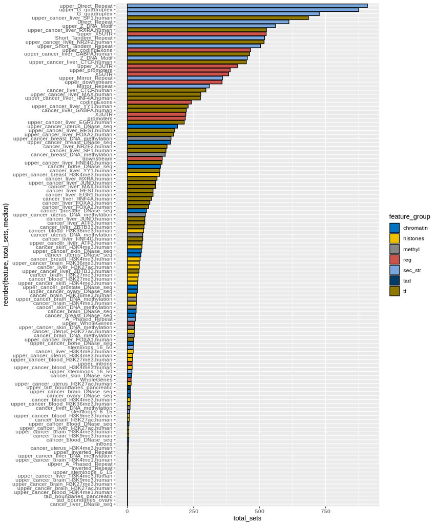

```r
ggplot(by_f, aes(x=reorder(feature, total_sets, median), y=total_sets, fill=feature_group))+
  geom_bar(stat="identity",color="black") +
  coord_flip() +
  scale_fill_jco()
```

Теперь выберем пул фичей для каждого типа рака.

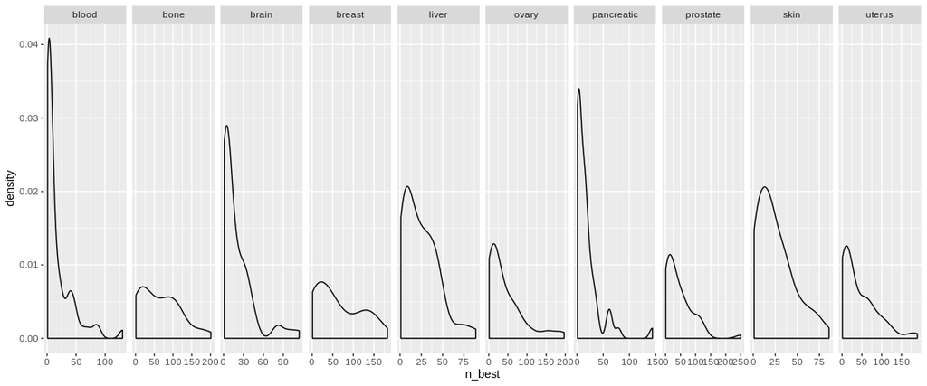

```r
ggplot(df_hits_last_iter_agg, aes(n_best)) +
  geom_density(alpha=0.5) +
  facet_grid(~cancer_type, scales = "free")
```

Видно, что 50 - для многих типов рака переходная граница между большим количеством фичей около 0 и небольшим количеством важных фичей. Выберем эти число как порог для выбора фичей.

```r
thr <- 50
df_hits_last_iter_agg %>%
  filter(n_best > 50) %>%
  group_by(cancer_type) %>%
  summarize(
    n_features = n()
  ) %>%
  arrange(n_features)
```

| cancer_type | n_features |
| --- | --- |
| brain | 4 |
| liver | 4 |
| blood | 5 |
| pancreatic | 5 |
| skin | 8 |
| ovary | 16 |
| prostate | 17 |
| bone | 19 |
| breast | 21 |
| uterus | 21 |

```r
res_hsp <- df_hits_last_iter_agg %>%
  mutate(boruta_selected = ifelse(n_best > thr, 1, 0)) %>%
  select(-thr)

res_hsp %>%
  filter(boruta_selected == 1) %>%
  ungroup() %>%
  select(feature) %>%
  unique() %>%
  nrow()
```

```
[1] 46
```

Всего 46 из 130 фичей

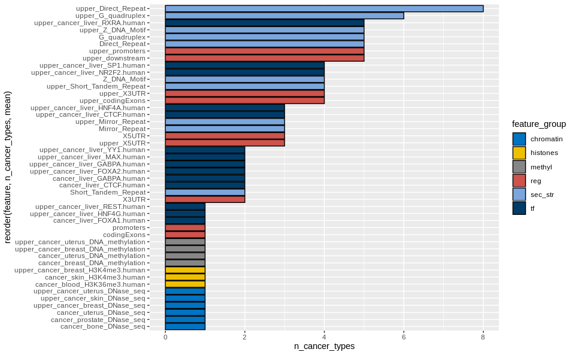

```r
cn_for_feat <- res_hsp %>%
  filter(boruta_selected == 1) %>%
  group_by(feature, feature_group) %>%
  summarize(n_cancer_types = n_distinct(cancer_type)) %>%
  arrange(desc(n_cancer_types))

ggplot(cn_for_feat, aes(x=reorder(feature, n_cancer_types, mean) , y=n_cancer_types,fill=feature_group))+
  geom_bar(stat="identity",color="black",  position="dodge") +
  coord_flip() +
  scale_fill_jco()
```

Heatmap for selected features

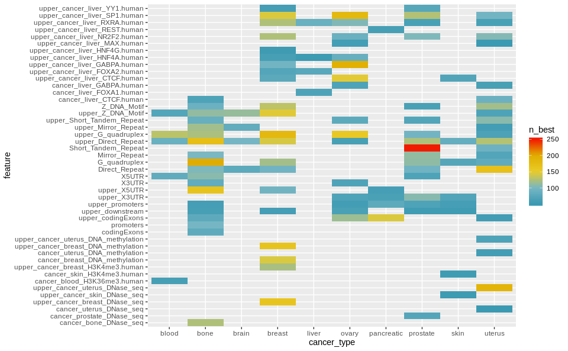

```r
ggplot(res_hsp %>% filter(boruta_selected == 1), aes(x=cancer_type, y=feature,fill=n_best)) +
  geom_tile() +
  scale_fill_gradientn(colours = pal)
```

```r
# wb <- createWorkbook()
# addWorksheet(wb, "hotspots_features")
# writeData(wb, sheet="hotspots_features", res_hsp)
# saveWorkbook(wb, "../data/output/boruta_stats.xlsx", overwrite = T)
```

### Cancer types clustering

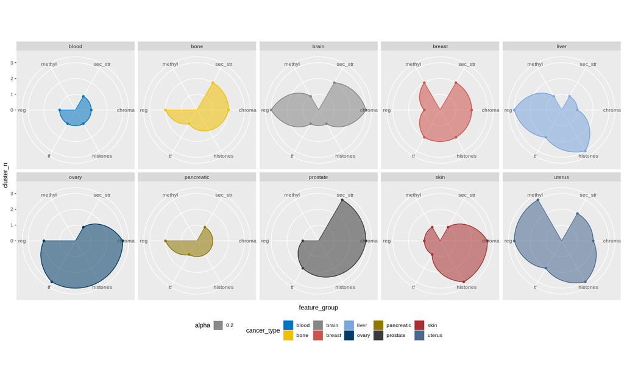

Нет идентичных типов рака, однако некоторые типы рака выглядят похоже, например:

- blood / pancreatic
- bone / brain
- ovary / prostate (!)
- breast / uterus (!)

```r
all_cl_raw <- dcast(all_cl_res, cancer_type ~ feature_group, value.var = "cluster_n")
all_cl_raw
```

[output not shown]

### Feature correlation

```r
best_features <- read.xlsx("../data/output/boruta_stats.xlsx", sheet = "hotspots_features")
best_features <- best_features[best_features$boruta_selected == 1,
                               c("cancer_type", "feature")]
best_features <- best_features %>% select(feature) %>% unique()
features_cols <- gsub(x=best_features$feature, pattern = "upper_", replacement = "") %>% unique()

# load data
win_len <- 100000
win_len_upper <- win_len * 10
data_path <- "../data/datasets/"
data <- read.csv(
  paste0(data_path, "dataset_", format(win_len, scientific = FALSE), ".csv")
)
source("features.R")
all_data <- get_higher_level_features(data=data, features_cols = features_cols,
                                           win_len_upper = win_len_upper,
                                           path_to_upper_data = paste0(data_path, "dataset_",
                                                                       format(win_len_upper, scientific = FALSE), ".csv"))

corrm <- cor(all_data[best_features$feature], method="spearman")
corrm_m <- melt(corrm)

corrm_m %>%
  filter(Var1 != Var2) %>%
  arrange(desc(value)) %>%
  head(15)
corrm_m$Var1 <- factor(corrm_m$Var1, levels = best_features$feature %>% sort())
corrm_m$Var2 <- factor(corrm_m$Var2, levels = best_features$feature %>% sort())
ggplot(corrm_m , aes(x=Var1, y=Var2, fill=value)) +
  geom_tile() +
  scale_fill_gradientn(colours = pal) +
  theme(axis.text.x = element_text(angle = 45, hjust = 1))
```

[output not shown]

```r
ggplot(corrm_m %>% filter(Var1 != Var2), aes(value)) +
  geom_histogram()
```

[output not shown]

```r
corrm_m %>%
  filter(Var1 != Var2) %>%
  filter(value >= 0.8) %>%
  arrange(desc(value))
```

[output not shown]